# Patient demographics

Author

Alexander W. Gofton & Emily Smith

Published

March 13, 2026

## Setup

Load CSIRO colour palette and required R packages.

```r
source("code/CSIRO_colours.R")

library(sf)
library(tidyverse)
```

## Load Data

Import the deduplicated (one record per patient) dataset, filtered to tests from 2014-2024.

```r
data_no_multi <- read.csv("data/preprocessed_with_SA_info_no_multi.csv") %>%
  filter(YOT >= 2014 & YOT <= 2024)
```

## Load Data with Multiple Tests

Import the full dataset retaining all test records per patient, filtered to 2014-2024.

```r
data_with_multi <- read.csv("data/preprocessed_with_SA_info.csv") %>%
  filter(YOT >= 2014 & YOT <= 2024)
```

# Basic Statistics

Calculate overall test counts, positivity rates, and detailed breakdowns by test result status.

## All Tests (Including Repeat Tests)

Summarise total tests, positive and negative counts, and positivity rate across all test records.

```r
basic_stats <- data_with_multi %>%
  summarise(
    total_tests = n(),
    total_positive_tests = sum(Status == "Positive", na.rm = TRUE),
    total_negative_tests = sum(Status == "Negative", na.rm = TRUE),
    positivity_rate_percent = round(
      (total_positive_tests / total_tests) * 100,
      2
    )
  )

print("Basic Statistics for data_with_multi:")
print(basic_stats)

# Alternative breakdown showing counts and percentages
detailed_stats <- data_with_multi %>%
  count(Status) %>%
  mutate(
    percentage = round((n / sum(n)) * 100, 2),
    status_label = paste0(Status, ": ", n, " (", percentage, "%)")
  )

print("Detailed breakdown by test result:")
print(detailed_stats)

# Summary table for reporting
summary_table <- data_with_multi %>%
  summarise(
    `Total Tests` = n(),
    `Positive Results` = sum(Status == "Positive", na.rm = TRUE),
    `Negative Results` = sum(Status == "Negative", na.rm = TRUE),
    `Overall Positivity Rate (%)` = round(
      (sum(Status == "Positive", na.rm = TRUE) / n()) * 100,
      2
    )
  ) %>%
  pivot_longer(everything(), names_to = "Metric", values_to = "Value")

print("Summary Statistics Table:")
print(summary_table)
```

```
[1] "Basic Statistics for data_with_multi:"
  total_tests total_positive_tests total_negative_tests positivity_rate_percent
1       16564                 6882                 9680                   41.55
[1] "Detailed breakdown by test result:"
    Status    n percentage            status_label
1 Negative 9680      58.44 Negative: 9680 (58.44%)
2 Positive 6882      41.55 Positive: 6882 (41.55%)
3     <NA>    2       0.01           NA: 2 (0.01%)
[1] "Summary Statistics Table:"
# A tibble: 4 × 2
  Metric                        Value
  <chr>                         <dbl>
1 Total Tests                 16564
2 Positive Results             6882
3 Negative Results             9680
4 Overall Positivity Rate (%)    41.6
```

## Unique Patients Only

```r
basic_stats <- data_no_multi %>%
  summarise(
    total_tests = n(),
    total_positive_tests = sum(Status == "Positive", na.rm = TRUE),
    total_negative_tests = sum(Status == "Negative", na.rm = TRUE),
    positivity_rate_percent = round(
      (total_positive_tests / total_tests) * 100,
      2
    )
  )

print("Basic Statistics for data_with_multi:")
print(basic_stats)

# Alternative breakdown showing counts and percentages
detailed_stats <- data_with_multi %>%
  count(Status) %>%
  mutate(
    percentage = round((n / sum(n)) * 100, 2),
    status_label = paste0(Status, ": ", n, " (", percentage, "%)")
  )

print("Detailed breakdown by test result:")
print(detailed_stats)

# Summary table for reporting
summary_table <- data_with_multi %>%
  summarise(
    `Total Tests` = n(),
    `Positive Results` = sum(Status == "Positive", na.rm = TRUE),
    `Negative Results` = sum(Status == "Negative", na.rm = TRUE),
    `Overall Positivity Rate (%)` = round(
      (sum(Status == "Positive", na.rm = TRUE) / n()) * 100,
      2
    )
  ) %>%
  pivot_longer(everything(), names_to = "Metric", values_to = "Value")

print("Summary Statistics Table:")
print(summary_table)
```

```
[1] "Basic Statistics for data_with_multi:"
  total_tests total_positive_tests total_negative_tests positivity_rate_percent
1       14076                 5025                 9050                    35.7
[1] "Detailed breakdown by test result:"
    Status    n percentage            status_label
1 Negative 9680      58.44 Negative: 9680 (58.44%)
2 Positive 6882      41.55 Positive: 6882 (41.55%)
3     <NA>    2       0.01           NA: 2 (0.01%)
[1] "Summary Statistics Table:"
# A tibble: 4 × 2
  Metric                        Value
  <chr>                         <dbl>
1 Total Tests                 16564
2 Positive Results             6882
3 Negative Results             9680
4 Overall Positivity Rate (%)    41.6
```

# Summary of Unique Patients

Count unique patients by test result status and calculate the patient-level positivity rate.

```r
unique_patient_summary <- data_no_multi %>%
  summarise(
    total_unique_patients = n_distinct(pat_ID),
    unique_positive_patients = n_distinct(pat_ID[Status == "Positive"]),
    unique_negative_patients = n_distinct(pat_ID[Status == "Negative"])
  ) %>%
  mutate(
    positivity_rate_patients = round(
      (unique_positive_patients / total_unique_patients) * 100,
      2
    )
  )

print(unique_patient_summary)

# Alternative approach with more detailed breakdown
patient_status_summary <- data_no_multi %>%
  group_by(pat_ID) %>%
  summarise(
    patient_status = ifelse(any(Status == "Positive"), "Positive", "Negative"),
    .groups = "drop"
  ) %>%
  count(patient_status, name = "unique_patients") %>%
  mutate(
    percentage = round((unique_patients / sum(unique_patients)) * 100, 2)
  )

print(patient_status_summary)
```

```
  total_unique_patients unique_positive_patients unique_negative_patients
1                 14076                     5026                     9051
  positivity_rate_patients
1                    35.71
# A tibble: 3 × 3
  patient_status unique_patients percentage
  <chr>                    <int>      <dbl>
1 Negative                  9050      64.3
2 Positive                  5025      35.7
3 <NA>                         1       0.01
```

## Male-to-Female Ratio

Calculate the male-to-female ratio among all tested patients.

```r
# M:F ratio
# In all patients
data_no_multi %>%
  count(Sex) %>%
  summarise(MF_ratio_all_test = n[Sex == "M"] / n[Sex == "F"])
```

```
  MF_ratio_all_test
1         0.5434211
```

## Male-to-Female Ratio in Positive Patients

Calculate the male-to-female ratio among patients with a positive alpha-gal result.

```r
# In positive patients
data_no_multi %>%
  filter(Status == "Positive") %>%
  count(Sex) %>%
  summarise(MF_ratio_positive_tests = n[Sex == "M"] / n[Sex == "F"])
```

```
  MF_ratio_positive_tests
1               0.7057026
```

## Male Proportion Among All Tested Patients

Calculate the percentage of all tested patients who are male.

```r
# Percentage of all tests that were Male
data_no_multi %>%
  count(Sex) %>%
  mutate(`percentage of males in all tests` = round((n / sum(n)) * 100, 2)) %>%
  filter(Sex == "M")
```

```
  Sex    n percentage of males in all tests
1   M 4956                            35.21
```

## Male Proportion Among Positive Patients

Calculate the percentage of positive patients who are male.

```r
# Percentage of positive tests that were Male
data_no_multi %>%
  filter(Status == "Positive") %>%
  count(Sex) %>%
  mutate(
    `percentage of males in all positive tests` = round((n / sum(n)) * 100, 2)
  ) %>%
  filter(Sex == "M")
```

```
  Sex    n percentage of males in all positive tests
1   M 2079                                     41.37
```

# Age Analysis

Derive patient age at time of testing and examine age distributions across sex and test status groups.

```r
# Convert YOB to Age
data_no_multi <- data_no_multi %>%
  mutate(Age = YOT - YOB)

data_with_multi <- data_with_multi %>%
  mutate(Age = YOT - YOB)
```

## Age Distribution by Sex

Calculate summary statistics (min, median, mean, max, SD, IQR) of age at test for males and females.

```r
# Age distribution, all patients, Male and Female
data_no_multi %>%
  group_by(Sex) %>%
  summarise(
    min_age = min(Age, na.rm = TRUE),
    median_age = median(Age, na.rm = TRUE),
    mean_age = mean(Age, na.rm = TRUE),
    max_age = max(Age, na.rm = TRUE),
    sd_age = sd(Age, na.rm = TRUE),
    iqr_age = IQR(Age, na.rm = TRUE)
  )
```

```
# A tibble: 2 × 7
  Sex   min_age median_age mean_age max_age sd_age iqr_age
  <chr>   <int>      <dbl>    <dbl>   <int>  <dbl>   <dbl>
1 F           1         48     47.2      98   17.9      28
2 M           1         49     47.4      96   19.1      28
```

## Age Distribution in Positive Patients by Sex

Calculate age summary statistics for positive patients stratified by sex.

```r
# Positive patients, Males and Females
data_no_multi %>%
  filter(Status == "Positive") %>%
  group_by(Sex) %>%
  summarise(
    min_age = min(Age, na.rm = TRUE),
    median_age = median(Age, na.rm = TRUE),
    mean_age = mean(Age, na.rm = TRUE),
    max_age = max(Age, na.rm = TRUE),
    sd_age = sd(Age, na.rm = TRUE),
    iqr_age = IQR(Age, na.rm = TRUE)
  )
```

```
# A tibble: 2 × 7
  Sex   min_age median_age mean_age max_age sd_age iqr_age
  <chr>   <int>      <dbl>    <dbl>   <int>  <dbl>   <dbl>
1 F           3         55     52.1      97   17.9      25
2 M           1         53     49.8      96   19.6      29
```

## Positivity Rate by Sex (Unique Patients)

Calculate the positivity rate within each sex group using the deduplicated dataset.

```r
# Positivity % of each sex
data_no_multi %>%
  group_by(Sex) %>%
  summarise(
    total = n(),
    positive = sum(Status == "Positive", na.rm = TRUE),
    positivity_rate = round((positive / total) * 100, 2)
  )
```

```
# A tibble: 2 × 4
  Sex   total positive positivity_rate
  <chr> <int>    <int>           <dbl>
1 F      9120     2946            32.3
2 M      4956     2079            42.0
```

## Positivity Rate by Sex (All Tests)

Calculate the positivity rate within each sex group using all test records.

```r
# Positivity % of each sex for all tests
data_with_multi %>%
  group_by(Sex) %>%
  summarise(
    total = n(),
    positive = sum(Status == "Positive", na.rm = TRUE),
    positivity_rate = round((positive / total) * 100, 2)
  )
```

```
# A tibble: 2 × 4
  Sex   total positive positivity_rate
  <chr> <int>    <int>           <dbl>
1 F     10750     4123            38.4
2 M      5814     2759            47.4
```

## Age Categorisation

Assign patients to standard 10-year age categories and save the augmented datasets for use in risk ratio calculations.

```r
# Add age categories to each row
data_no_multi <- data_no_multi %>%
  mutate(
    Age_cat = case_when(
      Age <= 14 ~ "0-14",
      Age >= 15 & Age <= 24 ~ "15-24",
      Age >= 25 & Age <= 34 ~ "25-34",
      Age >= 35 & Age <= 44 ~ "35-44",
      Age >= 45 & Age <= 54 ~ "45-54",
      Age >= 55 & Age <= 64 ~ "55-64",
      Age >= 65 & Age <= 74 ~ "65-74",
      Age >= 75 & Age <= 84 ~ "75-84",
      Age >= 85 ~ "85+",
      TRUE ~ NA_character_
    )
  )

write.csv(data_no_multi, "data/preprocessed_no_multi_with_age_cat.csv")
```

```r
# Add age categories to each row
data_with_multi <- data_with_multi %>%
  mutate(
    Age_cat = case_when(
      Age <= 14 ~ "0-14",
      Age >= 15 & Age <= 24 ~ "15-24",
      Age >= 25 & Age <= 34 ~ "25-34",
      Age >= 35 & Age <= 44 ~ "35-44",
      Age >= 45 & Age <= 54 ~ "45-54",
      Age >= 55 & Age <= 64 ~ "55-64",
      Age >= 65 & Age <= 74 ~ "65-74",
      Age >= 75 & Age <= 84 ~ "75-84",
      Age >= 85 ~ "85+",
      TRUE ~ NA_character_
    )
  )

write.csv(data_with_multi, "data/preprocessed_with_multi_with_age_cat.csv")
```

## Age-Sex Histogram Plot Setup

Configure colour palette and ggplot theme for age-by-sex histogram figures.

```r
MALE_COLOR <- "black"
FEMALE_COLOR <- "grey60"

theme_set(
  theme_classic() +
    theme(
      panel.grid.major.y = element_line(
        colour = "grey60",
        linewidth = 0.1
      ),
      #panel.grid.minor = element_blank(),
      axis.text.x = element_text(size = 10, angle = 45, hjust = 1),
      axis.text.y = element_text(size = 10),
      axis.title.y = element_text(size = 11),
      axis.line = element_line(colour = "grey70"),
      axis.ticks = element_line(colour = "grey70"),
      text = element_text(family = "Arial"),
      legend.position = c(0.98, 0.98),
      legend.justification = c("right", "top"),
      legend.text = element_text(size = 8),
      legend.title = element_blank(),
      legend.key.width = unit(1, "cm"), # Add this line - width of rectangle
      legend.key.height = unit(0.4, "cm"), # Add this line - height of rectangle
      legend.box.background = element_rect(
        fill = "white",
        color = "grey70",
        linewidth = 0.5
      ),
      legend.margin = margin(2, 2, 2, 2)
    )
)
```

### All Patients

Create a grouped bar chart showing the age distribution of all tested patients by sex.

```r
age_dist_plot <- ggplot(data_no_multi, aes(x = Age_cat, fill = Sex)) +
  geom_bar(
    alpha = 0.7,
    position = position_dodge(width = 0.85),
    width = 0.8
  ) +
  labs(
    x = NULL,
    y = "Count",
    fill = "Sex"
  ) +
  scale_fill_manual(
    values = c(
      "M" = MALE_COLOR,
      "F" = FEMALE_COLOR
    ),
    labels = c("M" = "Male", "F" = "Female")
  ) +
  scale_y_continuous(
    expand = c(0, 0),
    limits = c(0, 1800)
  )
```

### Positive Patients

Create a grouped bar chart showing the age distribution of positive patients by sex.

```r
data_pos <- data_no_multi %>% filter(Status == "Positive")

age_dist_plot_pos <- ggplot(data_pos, aes(x = Age_cat, fill = Sex)) +
  geom_bar(
    alpha = 0.7,
    position = position_dodge(width = 0.85),
    width = 0.8
  ) +
  labs(
    x = "Age Category",
    y = "Count",
    fill = "Sex"
  ) +
  scale_fill_manual(
    values = c(
      "M" = MALE_COLOR,
      "F" = FEMALE_COLOR
    ),
    labels = c("M" = "Male", "F" = "Female")
  ) +
  scale_y_continuous(
    expand = c(0, 0)
  )
```

### Combined Figure

Stack the all-patient and positive-patient histograms into a two-panel figure (Figure 1) and save.

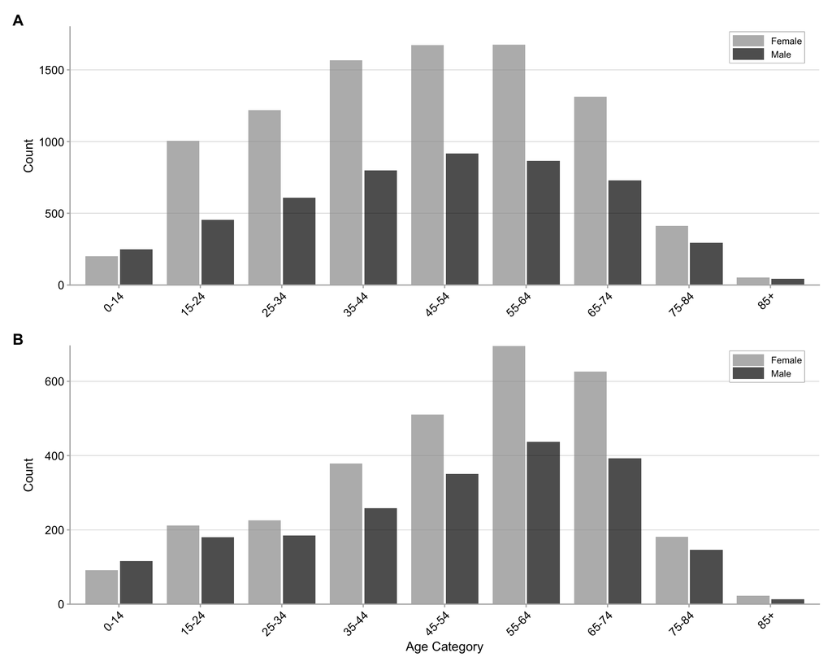

```r
# Combine plots
library(patchwork)

histograms <- age_dist_plot /
  age_dist_plot_pos +
  plot_annotation(tag_levels = 'A') &
  theme(plot.tag = element_text(face = "bold"))

histograms
```

```r
ggsave(
  "plots/Final_Plots/Fig_1_age_sex_histrograms.png",
  height = 12,
  width = 18,
  units = "cm",
  bg = "white",
  dpi = 300
)
```

# Statistical Tests

Apply non-parametric tests to assess differences in age distributions between demographic groups.

## Wilcoxon Rank-Sum Tests

Test for differences in median age between groups using the Wilcoxon rank-sum (Mann-Whitney U) test.

```r
# Pos vs neg For all tested patients
wilcox_all <- wilcox.test(Age ~ Status, data = data_no_multi)

print(wilcox_all)
```

```
    Wilcoxon rank sum test with continuity correction

data:  Age by Status
W = 18057537, p-value < 2.2e-16
alternative hypothesis: true location shift is not equal to 0
```

```r
# Males v Females For all tested patients
wilcox_all <- wilcox.test(Age ~ Sex, data = data_no_multi)

cat("=== WILCOXON TEST: Males vs Females (All Tested) ===\n")
print(wilcox_all)
```

```
=== WILCOXON TEST: Males vs Females (All Tested) ===

    Wilcoxon rank sum test with continuity correction

data:  Age by Sex
W = 22288284, p-value = 0.1767
alternative hypothesis: true location shift is not equal to 0
```

```r
# Males v Females For positive patients only
wilcox_positive <- wilcox.test(
  Age ~ Sex,
  data = data_no_multi %>% filter(Status == "Positive")
)
cat("\n=== WILCOXON TEST: Males vs Females (Positive Only) ===\n")
print(wilcox_positive)
```

```
=== WILCOXON TEST: Males vs Females (Positive Only) ===

    Wilcoxon rank sum test with continuity correction

data:  Age by Sex
W = 3238860, p-value = 0.0004917
alternative hypothesis: true location shift is not equal to 0
```

### Positive vs Negative Females

Compare age distributions between positive and negative female patients.

```r
# Positive vs all tested Females
females_data <- data_no_multi %>%
  filter(Sex == "F")

wilcox_fem_pos <- wilcox.test(
  Age ~ Status,
  data = females_data,
  exact = FALSE
)

cat("\n=== WILCOXON TEST: Positive females vs all tested females ===\n")
print(wilcox_fem_pos)
```

```
=== WILCOXON TEST: Positive females vs all tested females ===

    Wilcoxon rank sum test with continuity correction

data:  Age by Status
W = 6849948, p-value < 2.2e-16
alternative hypothesis: true location shift is not equal to 0
```

### Positive vs Negative Males

Compare age distributions between positive and negative male patients.

```r
# Positive vs all tested Females
males_data <- data_no_multi %>%
  filter(Sex == "M")

wilcox_male_pos <- wilcox.test(
  Age ~ Status,
  data = males_data,
  exact = FALSE
)

cat("\n=== WILCOXON TEST: Positive females vs all tested males ===\n")
print(wilcox_male_pos)
```

```
=== WILCOXON TEST: Positive females vs all tested males ===

    Wilcoxon rank sum test with continuity correction

data:  Age by Status
W = 2563928, p-value < 2.2e-16
alternative hypothesis: true location shift is not equal to 0
```

## Kolmogorov-Smirnov Tests

This tests whether the distributions differ in shape, not just central tendency:

```r
# Pos vs Neg
data_pos <- data_no_multi %>%
  filter(Status == "Positive") %>%
  pull(Age)

data_neg <- data_no_multi %>%
  filter(Status == "Negative") %>%
  pull(Age)

ks.pos.neg <- ks.test(data_pos, data_neg)

print(ks.pos.neg)
```

```
    Asymptotic two-sample Kolmogorov-Smirnov test

data:  data_pos and data_neg
D = 0.19003, p-value < 2.2e-16
alternative hypothesis: two-sided
```

```r
# Males vs Females For all tested patients
male_ages_all <- data_no_multi %>% filter(Sex == "M") %>% pull(Age)

female_ages_all <- data_no_multi %>% filter(Sex == "F") %>% pull(Age)

ks_all <- ks.test(male_ages_all, female_ages_all)

cat("=== KS TEST: Males vs Females (All Tested) ===\n")
print(ks_all)
```

```
=== KS TEST: Males vs Females (All Tested) ===

    Asymptotic two-sample Kolmogorov-Smirnov test

data:  male_ages_all and female_ages_all
D = 0.028597, p-value = 0.01047
alternative hypothesis: two-sided
```

```r
# Males vs Females For positive patients only
male_ages_pos <- data_no_multi %>%
  filter(Status == "Positive", Sex == "M") %>%
  pull(Age)

female_ages_pos <- data_no_multi %>%
  filter(Status == "Positive", Sex == "F") %>%
  pull(Age)

ks_positive <- ks.test(male_ages_pos, female_ages_pos)

cat("\n=== KS TEST: Males vs Females (Positive Only) ===\n")
print(ks_positive)
```

```
=== KS TEST: Males vs Females (Positive Only) ===

    Asymptotic two-sample Kolmogorov-Smirnov test

data:  male_ages_pos and female_ages_pos
D = 0.059954, p-value = 0.000313
alternative hypothesis: two-sided
```

```r
# Positive vs negative Females - KS test
females_data <- data_no_multi %>%
  filter(Sex == "F")

# Extract age by status
female_ages_positive <- females_data %>%
  filter(Status == "Positive") %>%
  pull(Age)

female_ages_negative <- females_data %>%
  filter(Status == "Negative") %>%
  pull(Age)

# Run KS test
ks_fem_pos <- ks.test(female_ages_positive, female_ages_negative)

cat("\n=== KS TEST: Positive females vs negative females ===\n")
print(ks_fem_pos)
```

```
=== KS TEST: Positive females vs negative females ===

    Asymptotic two-sample Kolmogorov-Smirnov test

data:  female_ages_positive and female_ages_negative
D = 0.21424, p-value < 2.2e-16
alternative hypothesis: two-sided
```

```r
# Positive vs negative Males - KS test
males_data <- data_no_multi %>%
  filter(Sex == "M")

# Extract age by status
male_ages_positive <- males_data %>%
  filter(Status == "Positive") %>%
  pull(Age)

male_ages_negative <- males_data %>%
  filter(Status == "Negative") %>%
  pull(Age)

# Run KS test
ks_male_pos <- ks.test(male_ages_positive, female_ages_negative)

cat("\n=== KS TEST: Positive females vs negative females ===\n")
print(ks_male_pos)
```

```
=== KS TEST: Positive females vs negative females ===

    Asymptotic two-sample Kolmogorov-Smirnov test

data:  male_ages_positive and female_ages_negative
D = 0.17345, p-value < 2.2e-16
alternative hypothesis: two-sided
```

## Effect Sizes (Cohen’s d)

Quantify the magnitude of age differences between groups using Cohen’s d with 95% confidence intervals, and classify effects as negligible, small, medium, or large.

```r
library(effectsize)

cohens_d_pos.neg <- cohens_d(Age ~ Status, data = data_no_multi)

# 1. Males vs Females - All tested patients
cohens_d_all <- cohens_d(Age ~ Sex, data = data_no_multi)

# 2. Males vs Females - Positive patients only
cohens_d_positive <- cohens_d(
  Age ~ Sex,
  data = data_no_multi %>% filter(Status == "Positive")
)

# 3. Positive vs Negative - Females only
cohens_d_females <- cohens_d(
  Age ~ Status,
  data = data_no_multi %>% filter(Sex == "F")
)

# 4. Positive vs Negative - Males only
cohens_d_males <- cohens_d(
  Age ~ Status,
  data = data_no_multi %>% filter(Sex == "M")
)

# Display all results
cat("=== EFFECT SIZES (Cohen's d) ===\n\n")

cat("Cohen's d for Positive vs Negative (All tested patients):\n")
print(cohens_d_pos.neg)
cat("\n")

cat("1. Males vs Females (All tested patients):\n")
print(cohens_d_all)
cat("\n")

cat("2. Males vs Females (Positive patients only):\n")
print(cohens_d_positive)
cat("\n")

cat("3. Positive vs Negative (Females only):\n")
print(cohens_d_females)
cat("\n")

cat("4. Positive vs Negative (Males only):\n")
print(cohens_d_males)
cat("\n")

# Create a summary table
effect_sizes_summary <- tibble(
  Comparison = c(
    "Males vs Females (All)",
    "Males vs Females (Positive only)",
    "Positive vs Negative (Females)",
    "Positive vs Negative (Males)"
  ),
  Cohens_d = c(
    cohens_d_all$Cohens_d,
    cohens_d_positive$Cohens_d,
    cohens_d_females$Cohens_d,
    cohens_d_males$Cohens_d
  ),
  CI_low = c(
    cohens_d_all$CI_low,
    cohens_d_positive$CI_low,
    cohens_d_females$CI_low,
    cohens_d_males$CI_low
  ),
  CI_high = c(
    cohens_d_all$CI_high,
    cohens_d_positive$CI_high,
    cohens_d_females$CI_high,
    cohens_d_males$CI_high
  ),
  Interpretation = case_when(
    abs(Cohens_d) < 0.2 ~ "Negligible",
    abs(Cohens_d) < 0.5 ~ "Small",
    abs(Cohens_d) < 0.8 ~ "Medium",
    TRUE ~ "Large"
  )
)

cat("=== SUMMARY TABLE ===\n")
print(effect_sizes_summary)
```

```
=== EFFECT SIZES (Cohen's d) ===

Cohen's d for Positive vs Negative (All tested patients):
Cohen's d |         95% CI
--------------------------
-0.33     | [-0.37, -0.30]

- Estimated using pooled SD.
1. Males vs Females (All tested patients):
Cohen's d |        95% CI
-------------------------
-0.01     | [-0.05, 0.02]

- Estimated using pooled SD.
2. Males vs Females (Positive patients only):
Cohen's d |       95% CI
------------------------
0.12      | [0.07, 0.18]

- Estimated using pooled SD.
3. Positive vs Negative (Females only):
Cohen's d |         95% CI
--------------------------
-0.41     | [-0.45, -0.37]

- Estimated using pooled SD.
4. Positive vs Negative (Males only):
Cohen's d |         95% CI
--------------------------
-0.21     | [-0.27, -0.16]

- Estimated using pooled SD.
=== SUMMARY TABLE ===
# A tibble: 4 × 5
  Comparison                       Cohens_d  CI_low CI_high Interpretation
  <chr>                               <dbl>   <dbl>   <dbl> <chr>
1 Males vs Females (All)            -0.0117 -0.0463  0.0229 Negligible
2 Males vs Females (Positive only)   0.123   0.0670  0.179  Negligible
3 Positive vs Negative (Females)    -0.409  -0.454  -0.365  Small
4 Positive vs Negative (Males)      -0.215  -0.271  -0.158  Small
```